# Homework 2

Bernard Fay; GitHub: bj99fay

2/5/2020

## R commands

1. Today’s temperature has a high of 24 and a low of 15 degree fahrenheit. Find the corresponding degress in celsius and storage it in a (single) vector named `cel`. Print the variable.

```r
high <- (24 - 32) * 5 / 9
low  <- (15 - 32) * 5 / 9
cel <- c(high, low)
names(cel) <- c('high', 'low')
cel
```

```
##      high       low
## -4.444444 -9.444444
```

2. Create a vector of length 200. The odd entries should be 3 and even entries should be 1. Storage the created in a variable named `vec200` and print.

```r
vec200 <- rep(c(3, 1), length.out=200)
vec200
```

```
##   [1] 3 1 3 1 3 1 3 1 3 1 3 1 3 1 3 1 3 1 3 1 3 1 3 1 3 1 3 1 3 1 3 1 3 1 3 1 3
##  [38] 1 3 1 3 1 3 1 3 1 3 1 3 1 3 1 3 1 3 1 3 1 3 1 3 1 3 1 3 1 3 1 3 1 3 1 3 1
##  [75] 3 1 3 1 3 1 3 1 3 1 3 1 3 1 3 1 3 1 3 1 3 1 3 1 3 1 3 1 3 1 3 1 3 1 3 1 3
## [112] 1 3 1 3 1 3 1 3 1 3 1 3 1 3 1 3 1 3 1 3 1 3 1 3 1 3 1 3 1 3 1 3 1 3 1 3 1
## [149] 3 1 3 1 3 1 3 1 3 1 3 1 3 1 3 1 3 1 3 1 3 1 3 1 3 1 3 1 3 1 3 1 3 1 3 1 3
## [186] 1 3 1 3 1 3 1 3 1 3 1 3 1 3 1
```

3. How many perfect squares are there between 1 and 2001? Storage the answer in a variable named `numPerfect` and print. You may want to look at `?round`.

```r
numPerfect <- floor(sqrt(2001))
numPerfect
```

```
## [1] 44
```

## Cars and mileage

For this part we will use the `mpg` data set, you can access the data by first installing (using `install.packages('ggplot2')`) and then loading the package `ggplot2` (using `library(ggplot2)`) into your R session. The `mpg` data includes information about fuel economy of popular car models for the years 1999 and 2008 as collected by the US Environmental Protection Agency. An answer should include a short paragraph of text for the explanation to a (human) reader, together with appropriate R code, outputs, and graphs.

Most exercises are from the ggplot2 book section 2.2.1. You might find it helpful for working on the homework to read through this section. *However, all questions can be solved by using just the basic R graphics functions.*

1. What are the 3 most fuel-efficient models in terms of highway mileage? Storage the data frame (with 3 rows) containing all information of these three cars in a variable named `top3` and print.

```r
mpgDF <- mpg[order(-mpg$hwy),]
top3 <- head(mpgDF, 3)
top3
```

```
## # A tibble: 3 x 11
##   manufacturer model   displ  year   cyl trans   drv     cty   hwy fl    class
##   <chr>        <chr>   <dbl> <int> <int> <chr>   <chr> <int> <int> <chr> <chr>
## 1 volkswagen   jetta     1.9  1999     4 manual~ f        33    44 d     compact
## 2 volkswagen   new be~   1.9  1999     4 manual~ f        35    44 d     subcom~
## 3 volkswagen   new be~   1.9  1999     4 auto(l~ f        29    41 d     subcom~
```

2. How many different compact models are included in this dataset? Storage the answer in a variable named `numCompact` and print.

```r
model <- subset(mpg, class == "compact", select=c("model"))
model <- unique(model)
numCompact <- nrow(model)
names(numCompact) <- "No. Compact"
numCompact
```

```
## No. Compact
##           8
```

3. Create a scatterplot of `hwy` and `cty` and describe the relationship. Why are there so few points visible? Explain your findings.

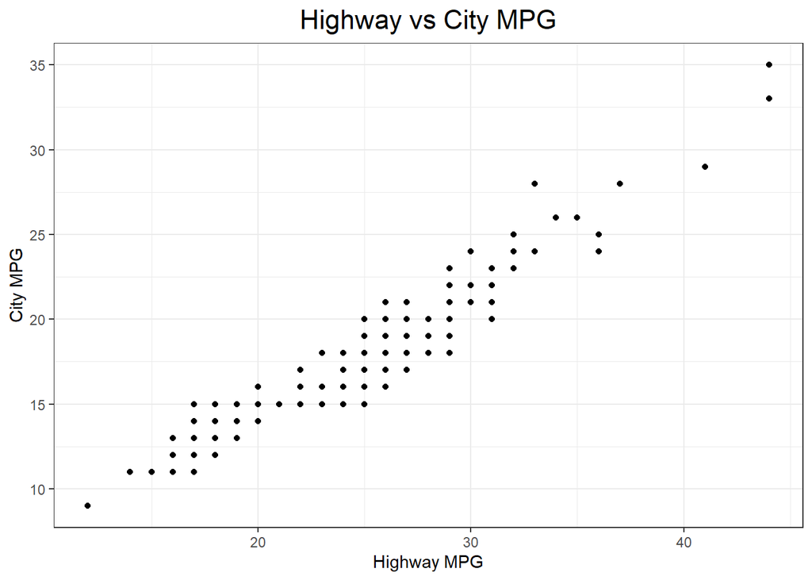

```r
ggplot(data=mpg, aes(x=hwy, y=cty, group=1)) +
    geom_point()+
    theme_bw()+
    theme(axis.title.y = element_text(size = rel(1)),
          axis.title.x = element_text(size = rel(1)),
          axis.text.x = element_text(size = rel(1)),
          axis.text.y = element_text(size = rel(1)),
          plot.title = element_text(hjust=0.5, size = rel(1.5)))+
    labs(x = "Highway MPG",
         y = "City MPG",
         title = "Highway vs City MPG")
```

There are so few points because serval of the vehicles share the same point on the scatter plot. This means that what would appear to be one point on the plot could actually be 8 different points that have the same value.

4. Are cars in 2008 more fuel efficient than cars in 1999? Use graphs *and* summary statistics to answer this question. Explain your findings.

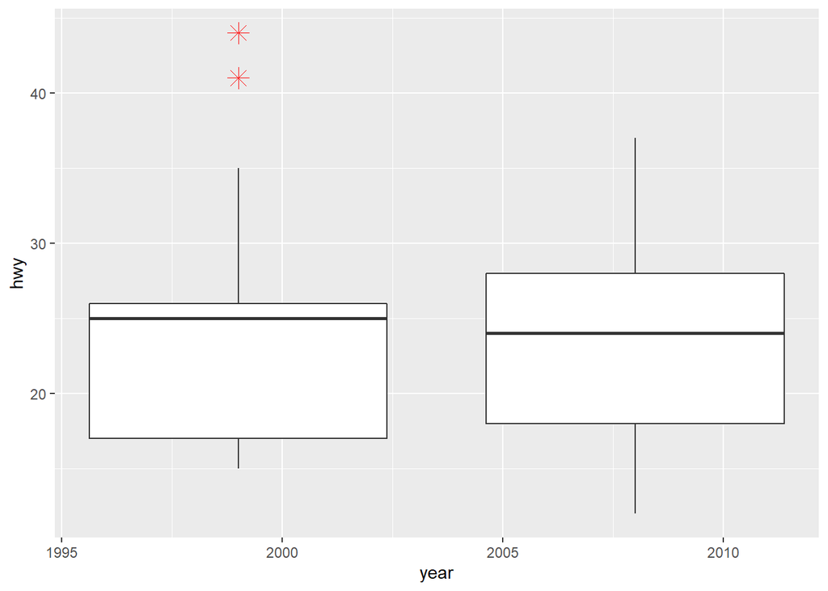

```r
cars0899 <- subset(mpg, year == 2008 | year == 1999, select=c("year", "cty", "hwy"))
ggplot(mpg, aes(x=year, y=hwy, group=year)) +
  geom_boxplot(outlier.colour="red", outlier.shape=8,
                outlier.size=4)
```

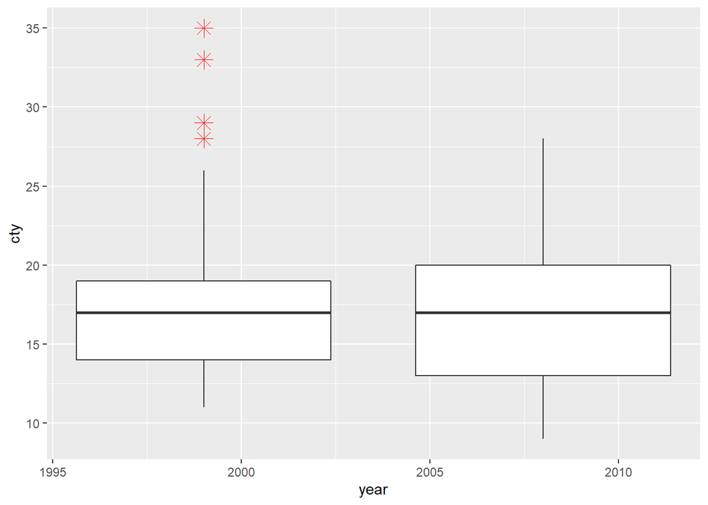

```r
ggplot(mpg, aes(x=year, y=cty, group=year)) +
  geom_boxplot(outlier.colour="red", outlier.shape=8,
                outlier.size=4)
```

```r
cars08 <- subset(mpg, year == 2008, select=c("cty", "hwy"))
cars99 <- subset(mpg, year == 1999, select=c("cty", "hwy"))
summary(cars99)
```

```
##       cty             hwy
##  Min.   :11.00   Min.   :15.00
##  1st Qu.:14.00   1st Qu.:17.00
##  Median :17.00   Median :25.00
##  Mean   :17.02   Mean   :23.43
##  3rd Qu.:19.00   3rd Qu.:26.00
##  Max.   :35.00   Max.   :44.00
```

```r
summary(cars08)
```

```
##       cty            hwy
##  Min.   : 9.0   Min.   :12.00
##  1st Qu.:13.0   1st Qu.:18.00
##  Median :17.0   Median :24.00
##  Mean   :16.7   Mean   :23.45
##  3rd Qu.:20.0   3rd Qu.:28.00
##  Max.   :28.0   Max.   :37.00
```